# User defined integration points

Haavard Rue `(hrue@r-inla.org)`

May 2017 (updated April 2019 and May 2023)

## Introduction

This short note describe a new option that allow the user to use user-defined integration points (or “design” points), instead of the default ones. The relevant integration in INLA does
$$\int f(x | \theta, y) \; \pi(\theta | y)
\;
d\theta = f(x | y)$$
where $\pi(\theta | y)$ is the approximated posterior marginal for the hyperparameters, and where $f(x | \theta, y)$ is the approximated marginal for $x$ for that configuration. The output of this integral is the posterior marginal $f(x|y)$. In practice, we use a discrete set of integration points for $\theta$, and corresponding weights $w$, to get
$$f(x|y) \approx \sum_i f(x|\theta_i, y) w_i \pi(\theta_i | y)$$
for which we require $w_i \ge 0$ and $\sum_i w_i = 1$. Usually, the integration is done in a *standardised scale*,
$$z = A(\theta - \gamma)$$
i.e. with respect to $\pi(z|y)$. Here, $\gamma$ is the mode of $\pi(\theta|y)$ and the matrix $A$ is the negative square root of the approximated covariance matrix for $\theta|y$ at the mode.

The relevant options are

```r
    opts = control.inla(int.strategy = "user", int.design = Design)
```

where `Design` is a matrix with the integration points and the integration weights. The $j$th row of `Design` consists of the values $\theta_j = (\theta_{1j}, \ldots, \theta_{mj})$, and the integration weight for this configuration, $w_j$. The values are in the $\theta$-scale, meaning that you have to know exactly what you are doing, including knowing the ordering of the hyperparameters.

Another version, is to define the points in the standardised scale $z$. To do this, use

```r
    opts = control.inla(int.strategy = "user.std", int.design = Design)
```

instead. The meaning of `Design` is unchanged, except that these can be given in standardised coordinates. This version is more relevant if you want to implement a generic new integration design instead of the ones already provided.

## First example

In this artificial example, we want to compute the change of the marginal variance of one component, $x_1$, of a hidden AR$(1)$ process, with respect to lag one correlation $\rho$. So we want to compute
$$\frac{\partial \mbox{SD}(x_1|y)}{\partial \rho}$$
for a fixed value of $\rho = \rho_0$. We have to compute a numerical approximation, using finite difference. While doing this, it is a good idea to keep the design fixed, to avoid introducing an error for changing that part as well.

Let us first setup the experiment

```r
n = 100
rho = 0.9
x = scale(arima.sim(n, model = list(ar = rho)))
y = x + rnorm(n, sd = 0.1)
```

this gives the following

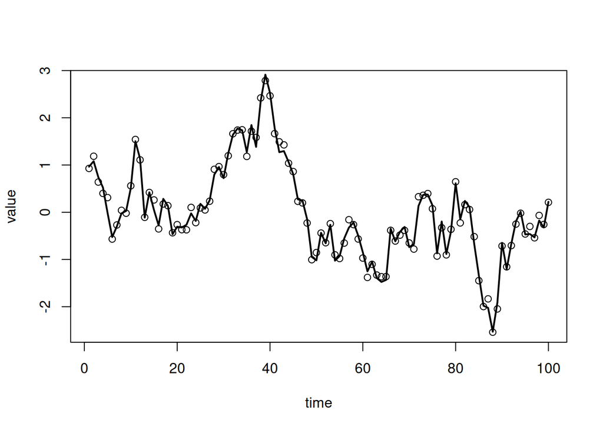

```r
plot(y, xlab = "time", ylab = "value")
lines(x, lwd=2)
```

To compute the derivative, we do

```r
rho.0 = rho
to.theta = inla.models()$latent$ar1$hyper$theta2$to.theta
rho.0.internal = to.theta(rho.0)

r = inla(y ~ -1 + f(time, model="ar1",
    hyper = list(
        theta1 = list(prior = "loggamma",
                      param = c(1,1)),
        theta2 = list(initial = rho.0.internal,
                      fixed=TRUE))),
    control.inla = list(int.strategy = "grid"),
    data = data.frame(y, time = 1:n))

sd.0 = r$summary.random$time[1,"sd"]
print(sd.0)
```

```
## [1] 0.01215824
```

We will now change $\rho$ a little, while we keep the same integration points,

```r
summary(r)
```

[output not shown]

```r
nm <- nrow(r$summary.hyperpar)
Design = as.matrix(cbind(r$joint.hyper[, seq_len(nm)], 1))
head(Design)
```

```
##      Log precision for the Gaussian observations Log precision for time 1
## [1,]                                    5.459443            -0.46103839 1
## [2,]                                    5.459514            -0.29230636 1
## [3,]                                    5.459561            -0.17981834 1
## [4,]                                    5.459605            -0.07429770 1
## [5,]                                    5.459672             0.08398325 1
## [6,]                                    7.434113            -0.68684356 1
```

where the last column is the (un-normalised) integration weights. The integration weights should depend on the area associated with every point, but for simplicity we just set the weights to be a constant.

`Design` has dimension 35, 3. We call `inla()` again reusing the previous found mode

```r
h.rho = 0.01
rho.1.internal = to.theta(rho.0 + h.rho)
rr = inla(y ~ -1 + f(time, model="ar1",
    hyper = list(
        theta1 = list(prior = "loggamma",
                      param = c(1,1)),
        theta2 = list(initial = rho.1.internal,
                      fixed=TRUE))),
    control.mode = list(result = r, restart=FALSE),
    data = data.frame(y, time = 1:n),
    control.inla = list(
        int.strategy = "user",
        int.design = Design))
sd.1 = rr$summary.random$time[1,"sd"]
print(sd.1)
```

```
## [1] 0.01047675
```

and then our estimate of the derivative is

```r
deriv.1 = (sd.1 - sd.0) / h.rho
print(deriv.1)
```

```
## [1] -0.1681494
```

PS: In the logfile of the `inla()`-call, the configurations are shown in the $z$ scale even for `int.strategy="user"`.

## Second example

There is also another (experimental) option, that is

```r
control.inla = list(int.stategy = "user.expert")
```

```r
n = 50
x = rnorm(n)
y = 1 + x + rnorm(n, sd = 0.2)
param = c(1, 0.04)
dz = 0.1
r.std = inla(y ~ 1 + x, data = data.frame(y, x),
             control.inla = list(int.strategy = "grid",
                                 dz = dz,
                                 diff.logdens = 8),
             control.family = list(
                 hyper = list(
                     prec = list(
                         prior = "loggamma",
                         param = param))))

s = r.std$internal.summary.hyperpar[1,"sd"]
m = r.std$internal.summary.hyperpar[1,"mean"]
theta = m + s*seq(-4, 4, by = dz)
weight = dnorm(theta,  mean = m, sd = s)

r = rep(list(list()), length(theta))
for(k in seq_along(r)) {
    r[[k]] = inla(y ~ 1 + x,
                  control.family = list(
                      hyper = list(
                          prec = list(
                              initial = theta[k],
                              fixed=TRUE))),
                  data = data.frame(y, x))
}
r.merge = inla.merge(r, prob = weight)
```

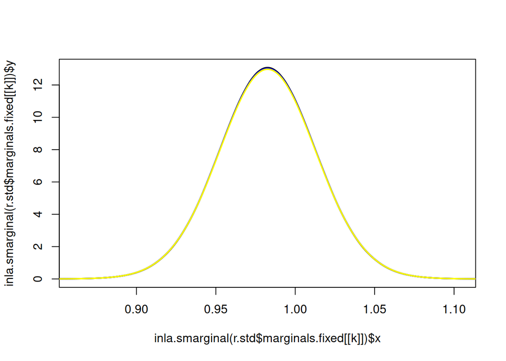

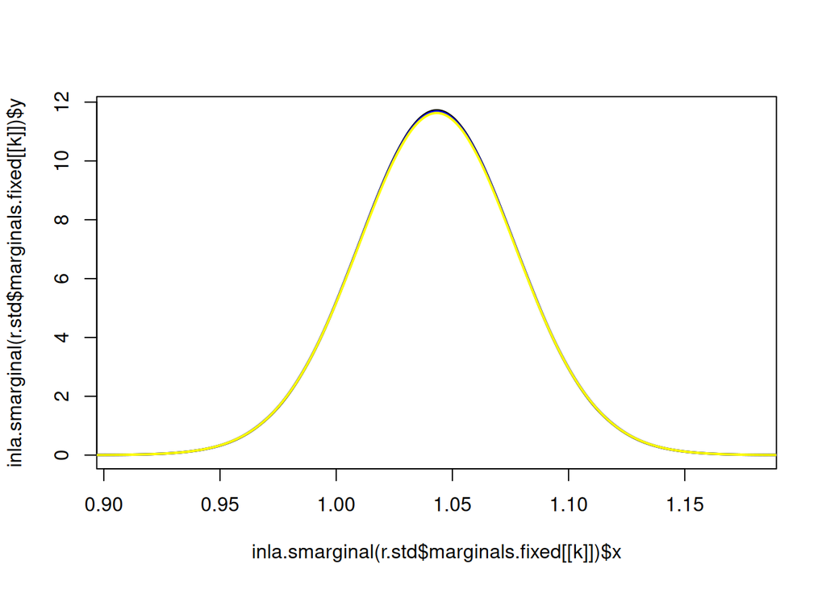

```r
r.design = inla(y ~ 1 + x,
                data = data.frame(y, x),
                control.family = list(
                    hyper = list(
                        prec = list(
                            ## the prior here does not really matter, as we will override
                            ## it with the user.expert in any case.
                            prior = "pc.prec",
                            param = c(1, 0.01)))),
                control.inla = list(int.strategy = "user.expert",
                                    int.design = cbind(theta, weight)))
for(k in 1:2) {
    plot(inla.smarginal(r.std$marginals.fixed[[k]]),
         lwd = 2, lty = 1, type = "l",
         xlim = inla.qmarginal(c(0.0001, 0.9999), r.std$marginals.fixed[[k]]))
    lines(inla.smarginal(r.design$marginals.fixed[[k]]),
          lwd = 2, col = "blue", lty = 1)
    lines(inla.smarginal(r.merge$marginals.fixed[[k]]),
          lwd = 2, col = "yellow", lty = 1)
}
```